# Coursera Practical Machine Learning Project

Naqeeb Asif

10 March 2018

# Synopsis

In this experiment [Weight Lifting Exercise Dataset](http://web.archive.org/web/20161224072740/http:/groupware.les.inf.puc-rio.br/har) is explored. It is first processed then three prediction algorithms namely “Decision Tree”, “Linear Discriminant Analysis” and “Random Forest” are trained on the dataset. After training it is found out that “Random Forest” outperforms the others.After the training the final model is used to predict the unknown data.

# Loading the data

In this secton the data is loaded.

```r
if(!file.exists("./data")){
  dir.create("./data")
}
download.file("https://d396qusza40orc.cloudfront.net/predmachlearn/pml-training.csv",destfile = "./data/pml-training.csv")
download.file("https://d396qusza40orc.cloudfront.net/predmachlearn/pml-testing.csv",destfile = "./data/pml-testing.csv")
training_orig <- read.csv("./data/pml-training.csv", na.strings = c("NA", ""))
testing_orig <- read.csv("./data/pml-testing.csv",na.strings = c("NA", ""))
```

# Data Processing

In this section data is processed first so that it can be used by the prediction algorithms.

## Data Cleanining

In this section the data is cleaned. First 7 columns of the data are removed as they do not seem to play major role in predicting the outcome.

```r
training <- training_orig[,-c(1:7)]
testing <- testing_orig[,-c(1:7)]
```

Following code will remove those columns which contain NA values as they are going to impact less on the prediction.

```r
col_rem <- integer()
for(i in 1:ncol(training)){
  total_NAs <- sum(is.na(training[,i]))
  if(total_NAs!=0){
    col_rem <- c(col_rem,i)
  }
}
training <- training[,-col_rem]
testing<- testing[,-col_rem]
```

After cleaning the training set it has `19622` observations and `53` features with `classe` as its `53rd` feature. The observations of testing set remains the same i.e. `20` but just like the training set the features of the training set become `53` with `problem_id` as its `53rd` feature (testing set does not contain the “classe” feature insted it contains “problem_id”).

## Data Splitting

In this section splitting of the data is performed. As the testing set does not contain the outcome feature so we’ll split the training set into two parts. 70% of the data is considered as training data while other 30% data is considered as cross validation data.

```r
library(caret)
set.seed(1234)
inTrain <- createDataPartition(training$classe,p=0.7,list = FALSE)
trainData <- training[inTrain,]
validationData <- training[-inTrain,]
```

# Prediction Model

## Creating model

This section contains a function which takes algorithm name , training set and testing set as its arguements and returns a list which contains the final model and confusion matrix for the testing set which will also help in reducing the code.

```r
createModel <- function(name,trainingData,testingData, ...){
  library(caret)
  result <- list()
  control <- trainControl(method = "cv", number = 5)
  result$model <- train(classe ~ .,data=trainingData,method = name, ...)
  pred <- predict(result$model,testingData)
  result$cm <- confusionMatrix(pred,testingData$classe)
  result
}
```

## Decision Trees

In this section, ‘the classification’Decision trees’ algorithm is used to fit the training data and the accuracy on validation data is caclculated from the confusion matrix which was found as a result from the function createModel .

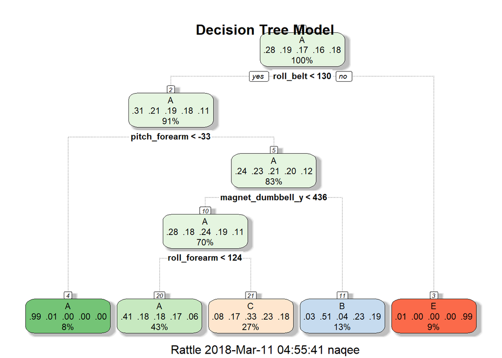

```r
library(caret)
library(rattle)
set.seed(1234)

dTreeModel <- createModel("rpart",trainData,validationData)
fancyRpartPlot(dTreeModel$model$finalModel,main="Decision Tree Model")
```

The cross-validation accuracy of the model is `48.904%`

## Linear Discriminant Analysis

In this section,‘Linear Discriminant Analysis’ algorithm is used to fit the training data and the accuracy on validation data is caclculated from the confusion matrix which was found as a result from the function createModel

```r
library(caret)
set.seed(1234)

ldaModel <- createModel("lda",trainData,validationData)
```

The cross-validation accuracy of the model is `70.484%`

## Random Forest

In this section,‘Random Forest’ algorithm is used to fit the training data and the accuracy on validation data is caclculated from the confusion matrix which was found as a result from the function createModel

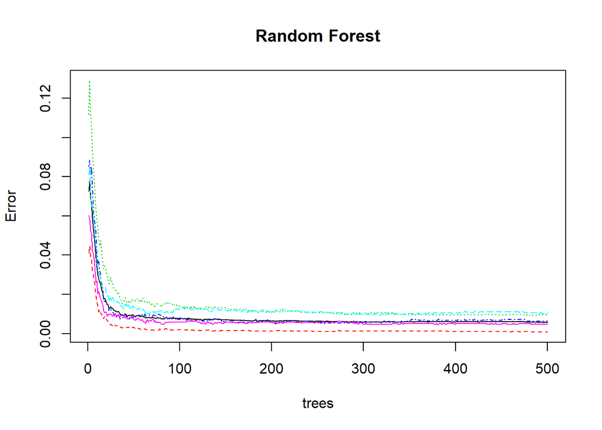

```r
library(caret)
library(doParallel)
registerDoParallel(cores = 4)
set.seed(1234)

rfModel <- createModel("rf",trainData,validationData)
plot(rfModel$model$finalModel,main = "Random Forest")
```

The cross-validation accuracy of the model is `99.439%`

## Best Classifier

Lets see which classifier is the best depending upon the accuracy.

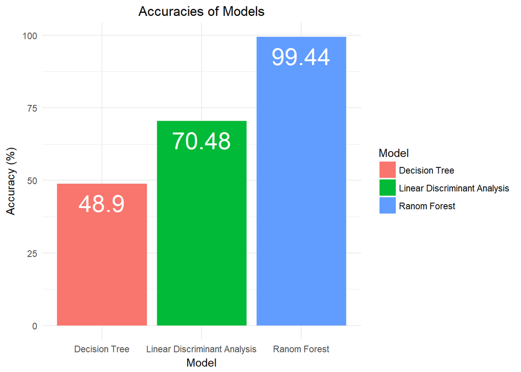

```r
library(ggplot2)
accuracy_df <- data.frame(Model=factor(c("Decision Tree","Linear Discriminant Analysis",
                                         "Ranom Forest")),
                                       accuracies=c(round(dTreeModel$cm$overall[1]*100,2),
                                                    round(ldaModel$cm$overall[1]*100,2),
                                                    round(rfModel$cm$overall[1]*100,2)))


ggplot(data=accuracy_df,aes(x=Model,y=accuracies,fill=Model)) + geom_bar(stat = "identity")+
  geom_text(aes(label=accuracies), vjust=1.6, color="white", size=8)+
  theme_minimal()+labs(title="Accuracies of Models") +ylab("Accuracy (%)")+
  theme(plot.title = element_text(hjust = 0.5))
```

As it can be seen from the plot that random forest gives the best accuracy out of all the models so we’ll choose this model to predict the outcome of unknown data.

# Prediction of testing dataset

In this section pridction of testing data is made using random forest model.

```r
bestModel <- rfModel$model
predict(bestModel,testing)
```

```
##  [1] B A B A A E D B A A B C B A E E A B B B
## Levels: A B C D E
```

# Conclusion

To conclude we can say that out of all the alogrithms used in this experiment random forest performs the best. But this performance comes with a price which is the training time of random forest is so much longer than that of other algorithms used in the experiment.